# Plot Group Means

Here I’ll show you how to plot the means for several groups. First, I’ll show you how to do it in a way that’s appropriate for publication in a journal and then I’ll show you how to add colors for a presentation.

First, let’s download a datafile.

```r
#Load the foreign package so we can import an SPSS file
if (!require(foreign)){
  install.packages("foreign", dependencies = TRUE)
  require(foreign)
}
#load the SPSS file into a variable called 'dataset.' Now I can access the SPSS file just by referring to 'dataset'
dataset = read.spss("https://osf.io/hwxre/download", to.data.frame=TRUE, use.value.labels = FALSE)
```

Lots of interesting variables in this dataset. Let’s compare how men and women differ in terms of age. The variable for gender in this dataset is called X.SEX. The variable for age is called X.AGE. X.SEX has two values (male/female) and X.AGE is continuous.

We’ll use ggplot2() to plot them, so let’s load that package now.

```r
if (!require(ggplot2)){
  install.packages("ggplot2", dependencies = TRUE)
  require(ggplot2)
}
```

Next, we’ll tell ggplot() which variables we’d like to plot.

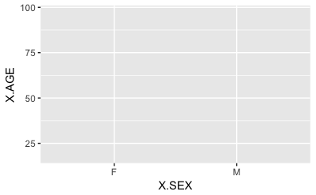

```r
ggplot(dataset, aes(x = X.SEX, y=X.AGE))
```

So far there is no data but at least we have our variables on the appropriate axes.

In ggplot(), we place things on the plot by adding layers.

Let’s start by adding a layer of bar graphs. We’ll do that with the stat_summary() layer.

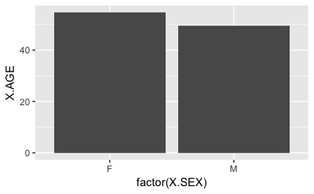

```r
ggplot(dataset, aes(x = factor(X.SEX), y=X.AGE)) + stat_summary(fun.y="mean", geom="bar")
```

It’s also possible to add a layer of bar graphs with the geom_bar() layer, but that is mostly used when you want to display frequencies or counts.

The stat_summary() layer allows you to plot various summary statistics besides the mean. You can also do median, mean_cl_boot (95% confidence interval), mean_sdl (standard deviation).

You can also use other types of plots besides bar graphs with the stat_summary() function. For example, point or line.

For my tastes, these bars are too wide. Let’s make them thinner so it is clearer to the audience that the variable on the x-axis (gender) is categorical. We’ll tell stat_summary() to make the bars 40% of the width allocated to the column’s space.

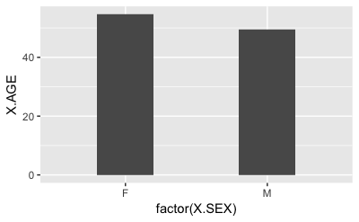

```r
ggplot(dataset, aes(x = factor(X.SEX), y=X.AGE)) + stat_summary(fun.y="mean", geom="bar", width=.4)
```

Next, let’s give the bars a black outline (color) and a white fill. We’ll do that through additional commands given to the stat_summary() layer.

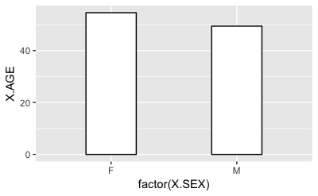

```r
ggplot(dataset, aes(x = factor(X.SEX), y=X.AGE))  + stat_summary(fun.y="mean", geom="bar", width=.4, color="black", fill="white")
```

Next, let’s get rid of the grid in the background by adding theme layers.

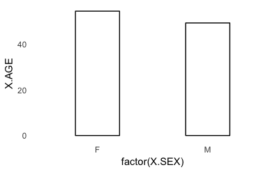

```r
ggplot(dataset, aes(x = factor(X.SEX), y=X.AGE)) + stat_summary(fun.y="mean", geom="bar", width=.4, color="black", fill="white") + theme_minimal() + theme(panel.grid = element_blank())
```

We told ggplot() to use the ‘minimal’ theme and then to tweak that theme a little but turning the grids in the background to white.

Next, let’s add the axis lines. We do that by adding commands to the theme() layer. We’ll tell that layer to make the axis lines black.

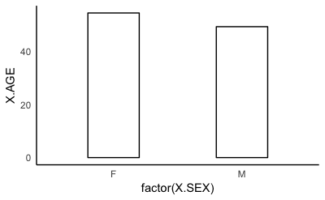

```r
ggplot(dataset, aes(x = factor(X.SEX), y=X.AGE)) + stat_summary(fun.y="mean", geom="bar", width=.4, color="black", fill="white") + theme_minimal() + theme(panel.grid = element_blank(), axis.line = element_line(color="black", size = .5))
```

Great! But it looks a little weird to have the x-axis line below the bottom of the bars. They look like they’re just hanging there.

First, let’s get rid of the x-axis. We’ll do that by changing the axis.line command to only refer to the y-axis.

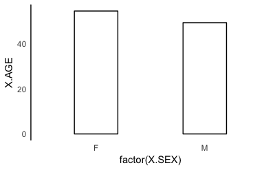

```r
ggplot(dataset, aes(x = factor(X.SEX), y=X.AGE)) + stat_summary(fun.y="mean", geom="bar", width=.4, color="black", fill="white") + theme_minimal() + theme(panel.grid = element_blank(), axis.line.y = element_line(color="black", size = .5))
```

Next, we’ll a new x-axis at the 0 value of the y-axis. We’ll do this by adding a layer called geom_hline(). This layers draws horizontal lines. We just have to tell it where.

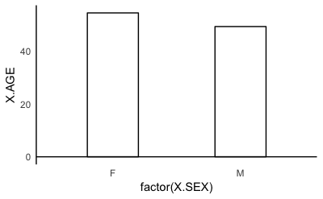

```r
ggplot(dataset, aes(x = factor(X.SEX), y=X.AGE)) + stat_summary(fun.y="mean", geom="bar", width=.4, color="black", fill="white") + theme_minimal() + theme(panel.grid = element_blank(), axis.line.y = element_line(color="black", size = .5)) + geom_hline(yintercept=0, color="black", size=.5)
```

Perfect!

Now let’s fix up the axes labels. X.AGE and factor(X.SEX) are not very professional! We can update these labels with the labs() layer.

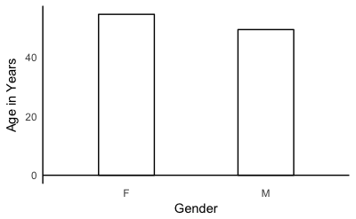

```r
ggplot(dataset, aes(x = factor(X.SEX), y=X.AGE)) + stat_summary(fun.y="mean", geom="bar", width=.4, color="black", fill="white")  + theme_minimal() + theme(panel.grid = element_blank(), axis.line.y = element_line(color="black", size = .5)) + geom_hline(yintercept=0, color="black", size=.5) + labs(x = "Gender", y = "Age in Years")
```

This is good. Our bar graph now clearly communicates the mean ages of women and men in the dataset. However, one problem with bar graphs is they tend to give the impression that either all the participants are exactly the mean age or no one is older than the mean age.

We can give the audience a clue about the range of data by changing the range on the y-axis. In this dataset, I believe the oldest person was over 90 years old, so let’s change the y-axis range to go all the way up to 90. We’ll do that with the coord_cartesian() layer.

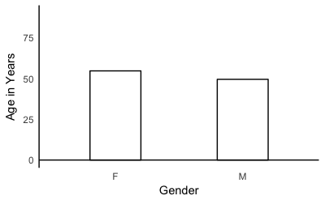

```r
ggplot(dataset, aes(x = factor(X.SEX), y=X.AGE)) + stat_summary(fun.y="mean", geom="bar", width=.4, color="black", fill="white")  + theme_minimal() + theme(panel.grid = element_blank(), axis.line.y = element_line(color="black", size = .5)) + geom_hline(yintercept=0, color="black", size=.5) + labs(x = "Gender", y = "Age in Years") + coord_cartesian(ylim = c(0, 90))
```

We can do even more though. We can add error bars to let the audience know about the variance in the distribution. First, we need a new package to do the calculations for us: Hmisc. Let’s load it now.

```r
if (!require(Hmisc)){
  install.packages("Hmisc", dependencies = TRUE)
  require(Hmisc)
}
```

Then, we’ll add another stat_summary() layer. This one will draw the 95% confidence intervals around the mean age for women and men.

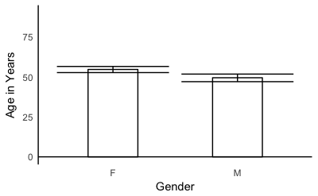

```r
ggplot(dataset, aes(x = factor(X.SEX), y=X.AGE)) + stat_summary(fun.y="mean", geom="bar", width=.4, color="black", fill="white") + theme_minimal() + theme(panel.grid = element_blank(), axis.line.y = element_line(color="black", size = .5)) + geom_hline(yintercept=0, color="black", size=.5) + labs(x = "Gender", y = "Age in Years") + coord_cartesian(ylim = c(0, 90)) + stat_summary(fun.data = "mean_cl_boot", geom = "errorbar")
```

Great! But the perpendicular lines on the error bars are way to wide. Let’s fix that by setting the width of each to just 5% of the total width allocated to their respective columns.

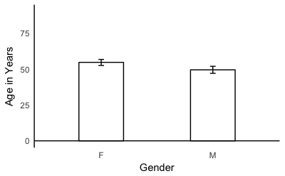

```r
ggplot(dataset, aes(x = factor(X.SEX), y=X.AGE)) + stat_summary(fun.y="mean", geom="bar", width=.4, color="black", fill="white") + theme_minimal() + theme(panel.grid = element_blank(), axis.line.y = element_line(color="black", size = .5)) + geom_hline(yintercept=0, color="black", size=.5) + labs(x = "Gender", y = "Age in Years") + coord_cartesian(ylim = c(0, 90)) + stat_summary(fun.data = "mean_cl_boot", geom="errorbar", width=.05)
```

Perfect!

This would be good to publish in a journal. Just be sure to tell your reader what the error bars represent. In this case they represent 95% confidence intervals. But they could also represent standard errors. You have tell your reader which.

Before we move on and make this graph more colorful for presentations, I want to point out that we still haven’t really captured how much variance there is in this dataset. The bar graph still kinda implies that most of the age values fall around the mean with very little variance. Let me add a jitter plot layer to demonstrate how most of the age values aren’t bunched around the mean.

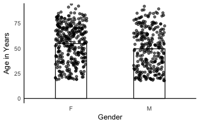

```r
ggplot(dataset, aes(x = factor(X.SEX), y=X.AGE)) + stat_summary(fun.y="mean", geom="bar", width=.4, color="black", fill="white") + theme_minimal() + theme(panel.grid = element_blank(), axis.line.y = element_line(color="black", size = .5)) + geom_hline(yintercept=0, color="black", size=.5)  + labs(x = "Gender", y = "Age in Years") + coord_cartesian(ylim = c(0, 90)) + stat_summary(fun.data = "mean_cl_boot", geom="errorbar", width=.05) + geom_jitter(width = .2, alpha = .6)
```

The disconnect between the actual variance in the data and what is visually implied by bar graphs with error bars is the basis of the argument for using box plots, violin plots, or both!

For now, though, let’s work on adding some color to our bar graph.

First let’s change the background. Often you will want to the background to match whatever color your presentation slides are. Let’s assume I’m using purple slides. We’ll do that by adding a plot.background command to the theme.

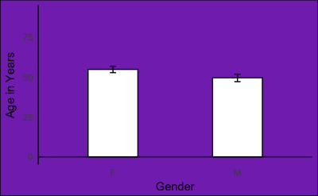

```r
ggplot(dataset, aes(x = factor(X.SEX), y=X.AGE))+ stat_summary(fun.y="mean", geom="bar", width=.4, color="black", fill="white") + theme_minimal() + theme(panel.grid = element_blank(), axis.line.y = element_line(color="black", size = .5), plot.background = element_rect(fill = "#8336BC"))  + geom_hline(yintercept=0, color="black", size=.5)  + labs(x = "Gender", y = "Age in Years")  + coord_cartesian(ylim = c(0, 90)) + stat_summary(fun.data = "mean_cl_boot", geom="errorbar", width=.05)
```

Now let’s add colors to the bars. We’ll tell ggplot to use different colors for each category. We’ll remove the fill command from stat_summary() and add it to the ggplot command. We’ll also remove the color command from stat_summary().

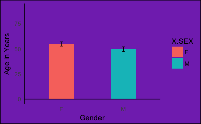

```r
ggplot(dataset, aes(x = factor(X.SEX), y=X.AGE, fill=X.SEX)) + stat_summary(fun.y="mean", geom="bar", width=.4) + theme_minimal() + theme(panel.grid = element_blank(), axis.line.y = element_line(color="black", size = .5), plot.background = element_rect(fill = "#8336BC"))  + geom_hline(yintercept=0, color="black", size=.5)  + labs(x = "Gender", y = "Age in Years")  + coord_cartesian(ylim = c(0, 90)) + stat_summary(fun.data = "mean_cl_boot", geom="errorbar", width=.05)
```

R automatically picks two colors for women and men. We can override R’s choice by adding a layer called: scale_fill_manual()

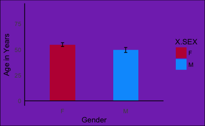

```r
ggplot(dataset, aes(x = factor(X.SEX), y=X.AGE, fill=X.SEX))  + stat_summary(fun.y="mean", geom="bar", width=.4)  + theme_minimal()  + theme(panel.grid = element_blank(), axis.line.y = element_line(color="black", size = .5), plot.background = element_rect(fill = "#8336BC"))  + geom_hline(yintercept=0, color="black", size=.5)  + labs(x = "Gender", y = "Age in Years")  + coord_cartesian(ylim = c(0, 90))  + stat_summary(fun.data = "mean_cl_boot", geom="errorbar", width=.05) + scale_fill_manual(values=c("#BE1C42","#009CFD"))
```

Notice, that ggplot() automatically added a legend when we told it to color the bars different colors. In other cases that could be useful, but we already have our bars clearly labeled by the x-axis. So let’s hide the legend. We do that by adding a command to the theme() layer: legend.position=“none”

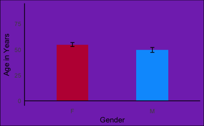

```r
ggplot(dataset, aes(x = factor(X.SEX), y=X.AGE, fill=X.SEX)) + stat_summary(fun.y="mean", geom="bar", width=.4) + theme_minimal() + theme(panel.grid = element_blank(), axis.line.y = element_line(color="black", size = .5), plot.background = element_rect(fill = "#8336BC"), legend.position="none") + geom_hline(yintercept=0, color="black", size=.5) + labs(x = "Gender", y = "Age in Years")  + coord_cartesian(ylim = c(0, 90)) + stat_summary(fun.data = "mean_cl_boot", geom="errorbar", width=.05)  + scale_fill_manual(values=c("#BE1C42","#009CFD"))
```

Now that the legend is gone, it’s become more obvious that it’s hard to read the values on the x- and y-axes. Let’s fix that by adding another command to the theme() layer.

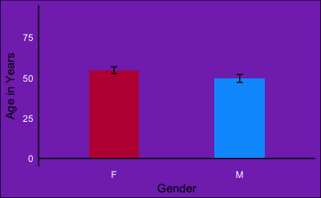

```r
ggplot(dataset, aes(x = factor(X.SEX), y=X.AGE, fill=X.SEX)) + stat_summary(fun.y="mean", geom="bar", width=.4) + theme_minimal() + theme(panel.grid = element_blank(), axis.line.y = element_line(color="black", size = .5), plot.background = element_rect(fill = "#8336BC"), legend.position="none", axis.text = element_text(color="white"))  + geom_hline(yintercept=0, color="black", size=.5) + labs(x = "Gender", y = "Age in Years") + coord_cartesian(ylim = c(0, 90)) + stat_summary(fun.data = "mean_cl_boot", geom="errorbar", width=.05) + scale_fill_manual(values=c("#BE1C42","#009CFD"))
```

It looks like white is much easier to read against the purple background so let’s change the x- and y- axis labels to white as well. Again, we’ll do that by adding a command to the theme() label.

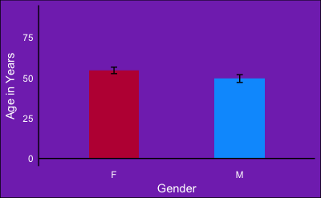

```r
ggplot(dataset, aes(x = factor(X.SEX), y=X.AGE, fill=X.SEX)) + stat_summary(fun.y="mean", geom="bar", width=.4) + theme_minimal() + theme(panel.grid = element_blank(), axis.line.y = element_line(color="black", size = .5), plot.background = element_rect(fill = "#8336BC"), legend.position="none", axis.text = element_text(color="white"),axis.title = element_text(color="white"))  + geom_hline(yintercept=0, color="black", size=.5) + labs(x = "Gender", y = "Age in Years") + coord_cartesian(ylim = c(0, 90)) + stat_summary(fun.data = "mean_cl_boot", geom="errorbar", width=.05) + scale_fill_manual(values=c("#BE1C42","#009CFD"))
```

Let’s change the axes lines to white as well. We’ll change the y-axis via a command to the theme() label but we’ll change the x-axis via a command to the hline() command.

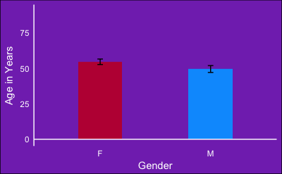

```r
ggplot(dataset, aes(x = factor(X.SEX), y=X.AGE, fill=X.SEX)) + stat_summary(fun.y="mean", geom="bar", width=.4) + theme_minimal() + theme(panel.grid = element_blank(), axis.line.y = element_line(color="white", size = .5), plot.background = element_rect(fill = "#8336BC"), legend.position="none", axis.text = element_text(color="white"), axis.title = element_text(color="white"))  + geom_hline(yintercept=0, color="white", size=.5) + labs(x = "Gender", y = "Age in Years") + coord_cartesian(ylim = c(0, 90)) + stat_summary(fun.data = "mean_cl_boot", geom="errorbar", width=.05) + scale_fill_manual(values=c("#BE1C42","#009CFD"))
```

Now let’s change the error bars to white as well. We’ll do that via a command to the stat_summary() label.

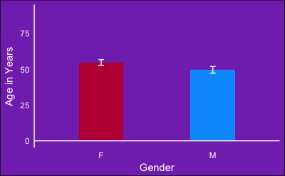

```r
ggplot(dataset, aes(x = factor(X.SEX), y=X.AGE, fill=X.SEX)) + stat_summary(fun.y="mean", geom="bar", width=.4) + theme_minimal() + theme(panel.grid = element_blank(), axis.line.y = element_line(color="white", size = .5), plot.background = element_rect(fill = "#8336BC"), legend.position="none", axis.text = element_text(color="white"), axis.title = element_text(color="white"))  + geom_hline(yintercept=0, color="white", size=.5) + labs(x = "Gender", y = "Age in Years") + coord_cartesian(ylim = c(0, 90)) + stat_summary(fun.data = "mean_cl_boot", geom="errorbar", width=.05, color="white") + scale_fill_manual(values=c("#BE1C42","#009CFD"))
```

One last thing we could add for a presentation would labels indicated the exact value of each bar. We can do that by adding anotation layers. First, let’s find out the exact value of each bar.

```r
#mean age for women
mean(dataset$X.AGE[dataset$X.SEX=="F"])
```

```
[1] 54.60472
```

```r
#mean age for men
mean(dataset$X.AGE[dataset$X.SEX=="M"])
```

```
[1] 49.42545
```

Next, we’ll add the annotation labels.

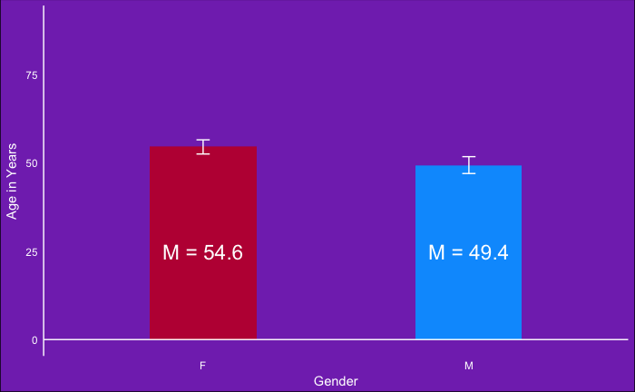

```r
ggplot(dataset, aes(x = factor(X.SEX), y=X.AGE, fill=X.SEX)) + stat_summary(fun.y="mean", geom="bar", width=.4) + theme_minimal() + theme(panel.grid = element_blank(), axis.line.y = element_line(color="white", size = .5), plot.background = element_rect(fill = "#8336BC"), legend.position="none", axis.text = element_text(color="white"), axis.title = element_text(color="white"))  + geom_hline(yintercept=0, color="white", size=.5) + labs(x = "Gender", y = "Age in Years") + coord_cartesian(ylim = c(0, 90)) + stat_summary(fun.data = "mean_cl_boot", geom="errorbar", width=.05, color="white") + scale_fill_manual(values=c("#BE1C42","#009CFD")) + annotate("text", label = "M = 54.6", x = "F", y = 25, color="white", size=6)+ annotate("text", label = "M = 49.4", x = "M", y = 25, color="white", size=6)
```